# Simulation and Imputation

Rob Leonard (robleonard@tamu.edu)

# Random Vector Generation

In this problem, we are going to be looking at the generating random vectors. Here are some simulation parameters we are going to use:

```r
set.seed(1)
n           = 100
p           = 3
rho         = 0.3
Sigma       = matrix(rho,nrow=p,ncol=p)
diag(Sigma) = 1
mu          = rep(5,p)

#Draw feature matrix from standard normal dist.
x = matrix(rnorm(n*p),nrow=n)
```

## Simulation

We want to simulate general random variables from standard ones, as in MMA 4.2, 2. (really it is the opposite. The book is discussing standardizing a general random vector. We want to generate a standard random vector and make it more general).

Form the square root of a matrix via the Cholesky decomposition in order to generate multivariate normal draws with a given mean and covariance.

```r
#Get square root here
SigmaSqRt_chol   = chol(Sigma)

# Transform x so that it's rows, X_i, are drawn from N(mu,Sigma)
x_chol = x %*% SigmaSqRt_chol
x_chol = x_chol + mu

#Print the sample covariance matrix
cov(x_chol)
```

```
##           [,1]      [,2]      [,3]
## [1,] 0.8067621 0.2412126 0.2576907
## [2,] 0.2412126 0.9070733 0.2262908
## [3,] 0.2576907 0.2262908 1.0280075
```

#### Compare Sigma to the sample covariance matrix.

The sample covariance matrix values aren’t terrible, but they aren’t close (say within 10%). For example, we want values of 1.0 in the diagonals but one value is only 0.81. I would expect the values to be closer as the sample size n increases to a much larger value.

## SVD

Now form the square root via the svd.

```r
SigmaSVD  = svd(Sigma)

SigmaSqRt_svd = SigmaSVD$u %*% diag(sqrt(SigmaSVD$d)) %*% t(SigmaSVD$u)

# Transform x so that it's rows, X_i, are drawn from N(mu,Sigma)
x_svd = x %*% SigmaSqRt_svd
x_svd = x_svd + mu

#Print the sample covariance matrix
cov(x_svd)
```

```
##           [,1]      [,2]      [,3]
## [1,] 0.8169132 0.2569098 0.2897785
## [2,] 0.2569098 0.9051101 0.2488008
## [3,] 0.2897785 0.2488008 1.0522635
```

#### Compare Sigma to this sample covariance matrix.

The sample covariance from svd is similar to Cholesky, and isn’t terribly close (within 10%). Again, the first element of the matrix is only 0.82 when it should be 1.0.

## Comparison via the law of large numbers

Let’s demonstrate via simulation that the two methods come up with the same square root. Note that we will ignore the mean `mu’ for this comparison as it doesn’t impact the covariance.

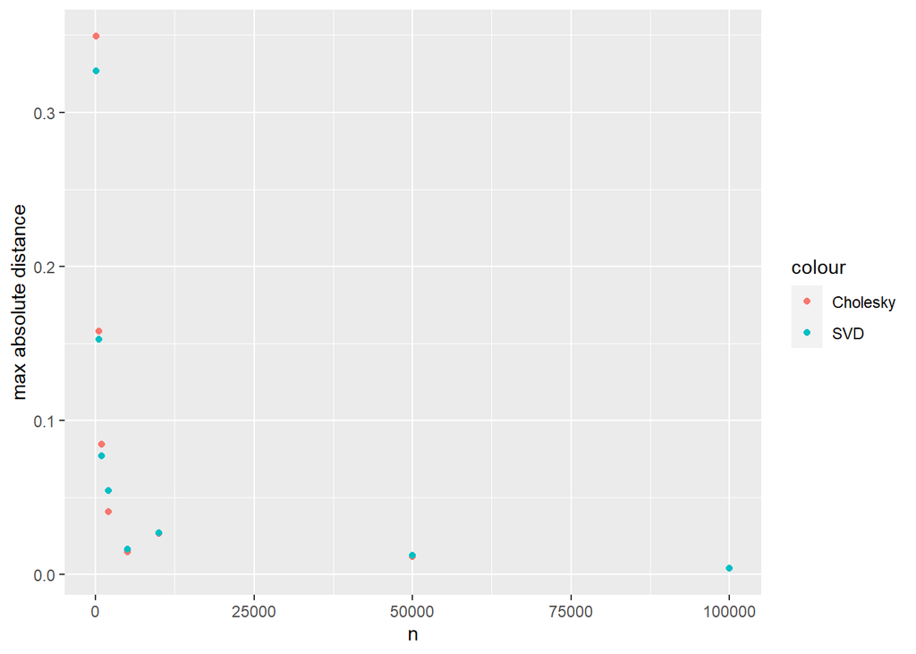

```r
nGrid = c(100,500,1000,2000,5000,10000,50000,100000)

results = data.frame('nGrid' = nGrid, 'svd' = rep(0, length(nGrid), 'chol' = rep(0, length(nGrid))))

nIter = 0
for(nSweep in nGrid){
  nIter    = nIter + 1
  xSweep   = matrix(rnorm(nSweep*p),nrow=nSweep)

  cov_chol = cov(xSweep %*% SigmaSqRt_chol)
  cov_svd  = cov(xSweep %*% SigmaSqRt_svd)

  results$chol[nIter] = max( abs(cov_chol - Sigma) )
  results$svd[nIter]  = max( abs(cov_svd - Sigma) )
}

ggplot(results) +
  geom_point(aes(nGrid, chol, color='Cholesky')) +
  geom_point(aes(nGrid, svd, color='SVD')) +
  labs(x = 'n', y = 'max absolute distance')
```

# Missing Data & Imputation

For this problem, extend the function explored in class to accomodate qualitative features.  
This should look like the following. Let’s adjust meanImputeF to just call a single column of the feature matrix:

```r
meanImputeF = function(x_j){
  M      = is.na(x_j)
  x_j[M] = mean(x_j,na.rm=TRUE)
  return(x_j)
}
```

Add a new function called modeImputeF that mimics meanImputeF:

```r
modeImputeF = function(x_j){
  M      = is.na(x_j)
  tbl = table(x_j)
  x_j[M] = names(tbl)[which.max(tbl)]
  return(x_j)
}
```

Now, we would want a third function called meanModeImputeF:

```r
meanModeImputeF = function(X){
  Ximpute = X
  M       = is.na(X)
  for(j in 1:ncol(X)){
    x_j = Ximpute[,j]
    if(is.character(x_j) | is.factor(x_j)){
      Ximpute[,j] = modeImputeF(X[,j])
    }
    else if(is.numeric(x_j)){
      Ximpute[,j] = meanImputeF(X[,j])
    }else{
      break
      warning('Not compatible data type detected')
    }
  }
  return(list('M' = M, 'Ximpute' = Ximpute))
}
```

```r
iterativeF = function(X, maxIters = 10, threshold = 1, verbose = TRUE){
  meanModeImpute  = meanModeImputeF(X)
  Ximpute         = meanModeImpute[['Ximpute']]
  M               = meanModeImpute[['M']]
  numericFeatures = sapply(Ximpute,is.numeric)

  converged = FALSE
  nIters    = 0
  while(!converged){
    nIters = nIters + 1
    Ximpute_old = Ximpute
    for(j in 1:ncol(X)){
      x_j = Ximpute[,j]
      if(is.character(x_j) | is.factor(x_j)){
        fitX_j           = glm(factor(x_j) ~ ., data = Ximpute[,-j], family = 'binomial')
        fitX_j_probs     = fitX_j$fitted.values[M[,j]]
        Ximpute[M[,j],j] = ifelse(fitX_j_probs > 1/2, 'fraud','notFraud')
      }
      if(is.numeric(x_j)){
        fitX_j = lm(Ximpute[,j] ~ ., data = Ximpute[,-j])
        Ximpute[M[,j],j] = fitX_j$fitted.values[M[,j]]
      }
    }
    status = max(abs(Ximpute_old[,numericFeatures] - Ximpute[,numericFeatures])/abs(Ximpute_old[,numericFeatures]))
    if(verbose){ print(status) }

    if( status < threshold){
      converged = TRUE
    }
    if( nIters >= maxIters){
      break
      warning('algorithm failed to converge')
    }
  }
  return(Ximpute)
}
```

# Simulation

```r
set.seed(1)
p               = 2
n               = 100
covarianceMat   = matrix(c(1,.75,.75,1),nrow=2)
X_cQuantitative = matrix(rnorm(n*p),nrow=n) %*% chol(covarianceMat)
X_cQualitative  = ifelse(rbinom(n,1,.2) == 1,'fraud','notFraud')

X_c             = data.frame('x1' = X_cQuantitative[,1],
                             'x2' = X_cQuantitative[,2],
                             'x3' = X_cQualitative)


X = X_c
X[X$x3 == 'fraud',2]     = NA
X[rbinom(n,1,.2) == 1,3] = NA
```

Impute this data set using the iterative scheme

```r
Xhat = iterativeF(X)  # returns Ximpute value
```

```
## [1] 13.94988
## [1] 0.9543573
```

We can check the unknown truth compared with our imputations via ‘table’, which cross-tabulates two qualitative vectors with each other. In this case, the diagonal elements record when we correctly imputed the observation and the off diagonals are where we incorrectly imputed.

```r
# only want to look at the results of the imputed values from discussion board post
table(Xhat$x3[is.na(X$x3)],X_c$x3[is.na(X$x3)])
```

```
##
##            fraud notFraud
##   fraud        5        9
##   notFraud     0        7
```

```r
correctImputation   = 12 # The number of correctly imputed observations - from main diagonal
```

I correctly imputed 12 observations